# BayWheels_part2 slides

## Part II - (Bay Wheels Bike System Findings )

by (**PURITY NJOKI NG'ANG'A**)

Introduction This data set includes information about individual rides made in a bike-sharing system covering the greater San Francisco Bay area for a period of three months.

## Dataset Overview

> This data set includes information about individual rides made in a bike-sharing system covering the greater San Francisco Bay area for three months(jan-march)

> The dataset used for this analysis was downloaded from amazonaws.com inform of zip files, each dataset for each month was downloaded individually, assesed and joined together to form a master dataframe used in the wrangling and visualization process.

# Cleaning Data

# Exploratory Data Analysis

## Visualization 1

## (a) How long does an Average trip take/ Average duration?

The average duration of a trip is between 3- 15 minutes.

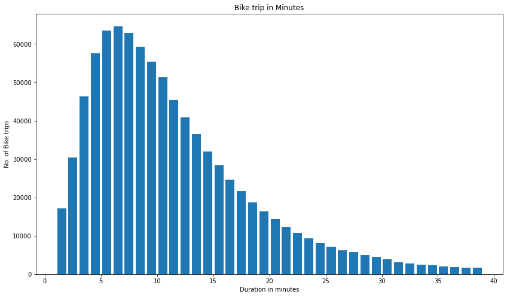

## Visualization 2

### (i) what are the proporions taken by each user type of the bike service?

### (ii) what is the popular method employed by the users?

This visualization is meant to view amount of proportions taken up by the user types and rental access methods.

- Subscribers take up larger proportions of the bike rides taken as compared to the customers, who only take up about 40%.
- Most riders rent the bikes using the app method, wich takes up to about 92%, while the dipper method only takes up 7.7%.

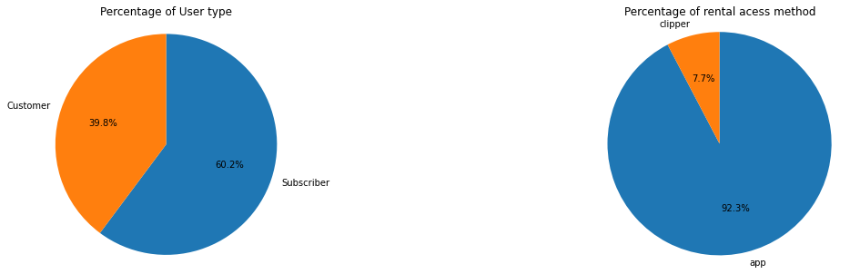

## Visualization 3

### Which month and day of the week most trips are taken?

### (i). Weekly trips

- Most trips are taken on wednesday. Seems like less trips are taken during the weekend.
- Most trips also end on wednesdays

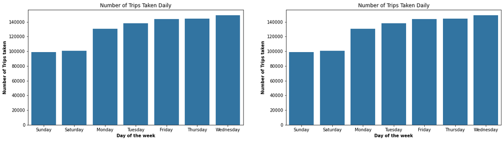

## (ii) Monthly Trips

- Most trips were taken in February, while least trips were taken in March

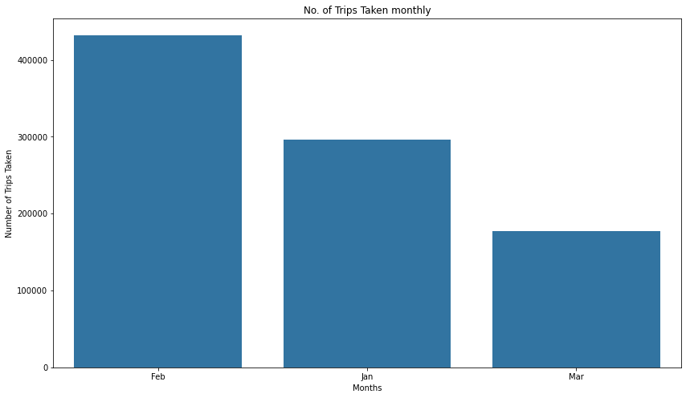

## Visualization 4

### (i) What is the trip duration according to the User type

At duration less than or equal to 60 minutes, both user types(Casual) and subscribersget almost equal amount of time of using the bikes.

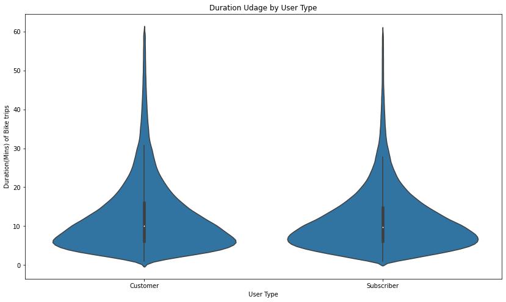

## Visulization 5

### (ii) What is the trip duration against the month?

-it was observed that most points fall between 1-60 minutes, The dataset was trimmed to perform an analysis on this part of the data. Shows that, according to each month, March take up the highest average duration for each bike trip, while the lowest average time is observed in january. To imply that bike rides duration has been increasing.

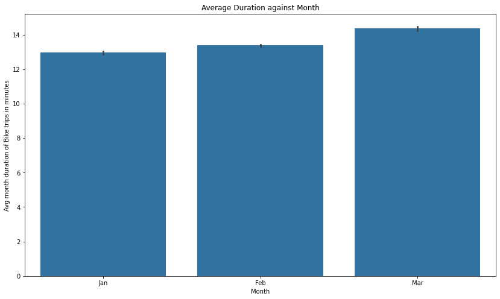

## Visualization 6

### (i) What is the Monthly trip durations of each user type?

- Viewed by month, according to the plot, customers had longer durations than subscribers.

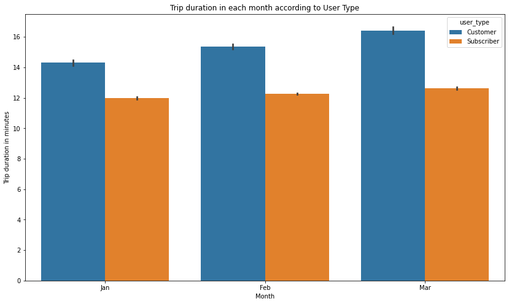

# Conclusion

- The idea has been successful, since the average trip duration has been increasing since january, through to february and reached its peak in march. This leads to conclusion that more people are depending on bikes to travel long distances.
- During weekdays, most trips are preffered on wednesdays
- Comparing the three months, most trips are preffered in February.
- Most trips are taken on shorter durations, but as for longer durations less and less trips are taken.